# Part1

## Practical session on D-statistics

haracterize the relationship among populations based on D-statistics. Distinguish between gene flow and ancestral polymorphism.

D-statistic (ABBA-BABA test) to detect past admixture events To discuss:

What is the difference between a population tree and a gene tree?

# 1. D-statistics to detect past admixture events

For this exercise we will use data simulated according to a model of human demography based on data from Malaspinas et al. (2016). This dataset includes data from two Neanderthal populations, 1 African population and 1 non-African.

The dataset is in the file “NeanderthalModel.geno”, and it is a genotype matrix similar to the Henn et al. data, with genotypes coded as 0 (homozygote for ancestral allele), 1 (heterozygote), 2 (homozygote for derived allele). Have a look at the file.

Follow the code below to solve these exercises. You will need to load the functions defined in the file: “Dstat_Jacknife.r”

## Exercise 1.

Read the datafile. How many SNPs? How many individuals per population?

```r
# load the file with the function to compute the D-stat
source("Dstat_Jacknife.r")

# read the data from the Simulated_Data
geno <- as.matrix(read.table("NeanderthalModel.geno", header=T, stringsAsFactors = F))
str(geno) # check what was read
```

```
##  int [1:435911, 1:4] 1 0 0 0 0 0 0 0 0 0 ...
##  - attr(*, "dimnames")=List of 2
##   ..$ : NULL
##   ..$ : chr [1:4] "NeaAltai" "NeaPop2" "African" "Australia"
```

4 individuals, 2 neandertals, 1 african and 1 australian 435911 snp

Exercise 2.

Modify the code below to:

- Test if Neanderthal contributed to Aboriginal Australians using the D-statistic (ABBA-BABA test).
- What is the order of populations you should consider? What is P1, P2, P3 and Outgroup?
- Based on the value of the D-statistic, is there evidence of admixture?
- Can you provide an estimate of the admixture proportion?
- Is the D-statistic significant? Use the jacknife approach to test this. Function Djack().

The code below was used to test if there is an excess of shared derived sites between a Neanderthal population and African. We will assume that the chimpanzee is the outgroup, and we assume that chimpanzees are fixed to the ancestral allele. Thus, we will add a column of zeros to our dataset that correspond to the genotypes of the outgroup (chimpanzee).

NOTE: You will need to modify the order of populations to the correct order!

```r
# load the file with the function to compute the D-stat
source("Dstat_Jacknife.r")

# add a column with the genotypes of the outgroup
# that we assume if fixed to the ancestral allele

# So we add a 100% ancestral allele column we called Chimp

geno <- cbind(geno, 0)
# add column name to the 5th column
colnames(geno)[5] <- "chimp"
# check that geno matrix has the correct dimension
str(geno)
```

```
##  num [1:435911, 1:5] 1 0 0 0 0 0 0 0 0 0 ...
##  - attr(*, "dimnames")=List of 2
##   ..$ : NULL
##   ..$ : chr [1:5] "NeaAltai" "NeaPop2" "African" "Australia" ...
```

```r
# individual names
inds <- colnames(geno)

# Population names in the order we want to compute the D-stat,
# that is, in the order P1, P2, P3, P4

# c("NeaAltai", "NeaPop2","Africa","chimp")
# p4 is right, p1, p2 are in group, p3 is an ancient group
# so we change the order to:

# This is just a random order
pop.names <- c("African", "Australia","NeaAltai","chimp")
#pop.names <- c("NeaAltai", "NeaPop2","Africa","chimp")

# Get the index of individuals from each population
# number of populations
npops <- length(pop.names)
# index of sampled individuals
sample_inds <- list() # list to save the index of individuals belonging to each pop
for(i in 1:npops) {
  # apply the function to detect which individuals belong to each pop
  sample_inds[[i]] <- which(substr(inds, 1, nchar(pop.names[i]))==pop.names[i])
}

# create a new genotype matrix ordered according to the sampled_inds
# That is a matrix with 4 columns corresponding to P1, P2, P3 and P4
# with an individual from each population
genoD <- geno[,sample_inds[[1]]]
for(i in 2:4) {
  genoD <- cbind(genoD, geno[,sample_inds[[i]]])
}
colnames(genoD) <- c(inds[sample_inds[[1]]],inds[sample_inds[[2]]],inds[sample_inds[[3]]],inds[sample_inds[[4]]])

# Need to get the index of individuals
# in this case since we have 1 individual per pop, the index is given by c(1,2,3,4)
ds <- dstat(genoD, index_inds = c(1:4))
ds$D # D-statistic
```

```
## [1] 0.07247692
```

```r
ds$abba # abba sites
```

```
## [1] 16843.25
```

```r
ds$baba # baba sites
```

```
## [1] 14566.75
```

We have more ABBA -> more snp common between Australian and Neanderthal than with african

```r
# get the estimates of significance based on the block-jacknife approach
dsj <- Djack(genoD, index_inds = c(1:4), numblocks = 10)
dsj$D # D-statistic
```

```
## [1] 0.07247692
```

```r
dsj$sd # standard deviation
```

```
## [1] 0.009753903
```

```r
dsj$z # z-score
```

```
## [1] 7.430556
```

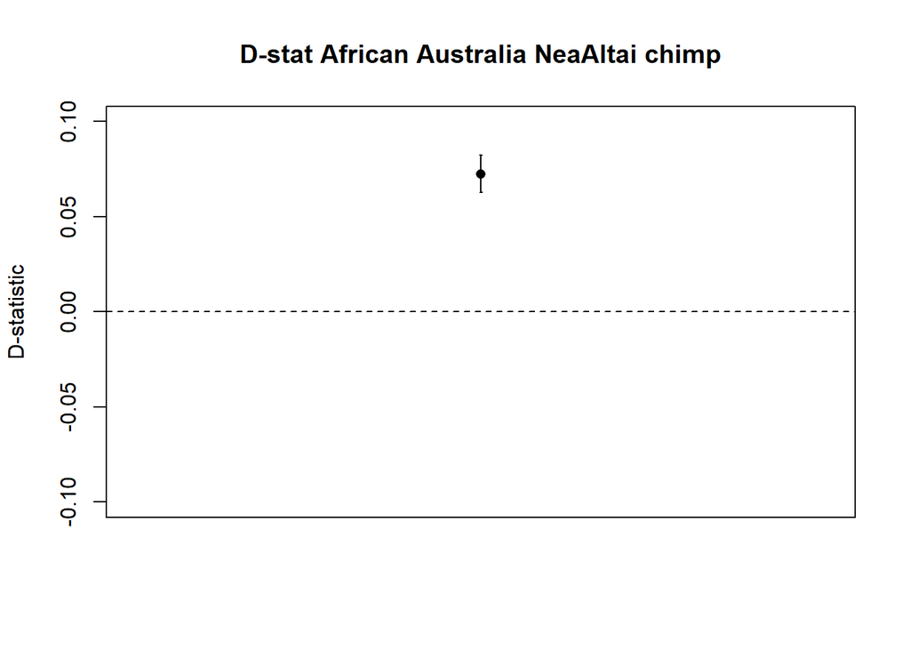

```r
plot(ds$D, ylim=c(-0.1, 0.1), xaxt='n', xlab="", ylab="D-statistic", main="D-stat African Australia NeaAltai chimp", pch=16, col=1)
add.error.bars(1, ds$D, dsj$sd, w=0.01, col=1)
abline(h=0, lty=2)
```

Note: with the two Neanderthal pop. we have approx. the same results. So it’s not important.

TO DISCUSS

- What is the population tree?

So we have the two human pop, then the neandertal then the chimp.

- What is the null hypothesis under the scenario of ancestral polymorphism/incomplete lineage sorting?

the number of abba and baba are the same

- Is the D-statistic significantly different from zero?
- How to estimate the admixture coefficient?

In our case yes,

- Is there evidence of admixture between Neanderthal and Aboriginal Australians?
- Is there evidence of admixture between Neanderthal and Africans?

We can’t answer these questions because this dataset is only with one sample, doesn’t explain the whole population. Here we can see that there is more abba than baba -> more neanderthal into australian than african. Doesn’t mean we have nothing from the Africans.